# Short tutorial of GridDER

Tainá Rocha, Xiao Feng, Yingying Xie, Xin Chen

27 January 2023

# 1 Introduction

The package is a tool for identifying biodiversity records that have been designated locations on widely used grid systems. Our tool also estimates the degree of environmental heterogeneity associated with grid systems, allowing users to make informed decisions about how to use such occurrence data in global change studies. We show that a significant proportion (~13.5%; 261 million; accessed November 2021) of records on GBIF, largest aggregator of natural history collection data, are potentially gridded data, and demonstrate that our tool can reliably identify such records and quantify the associated uncertainties.

# 2 Workflow for grid simulation and detection

[figure not shown]

# 3 Overview of functions in GridDER

| Purpose | New Name | Functionality |
| --- | --- | --- |
| internal function | find_angle | calculate angle between two points |
| internal function | find_crs_extent | automatically find the spatial extent of a coordinate reference system from https://epsg.io |
| data prep | load_occ | transform a txt file (e.g. a dataset from GBIF in DarwinCore format) that has decimalLongitude and decimalLatitude into simplified spatially points |
| metadata inference | infer_crs | infer the coordinate reference system in which a set of gridded coordinates were originally defined |
| metadata inference | infer_resolution | estimate the resolution (or regular spacing of input coordinates) along horizontal and vertical axes, based on distance to nearest neighbors along four directions (i.e. up, down, left, right) |
| metadata inference | infer_origin | infer the origin a grid system while considering the small uncertainty of the coordinates |
| metadata inference | infer_extent | infer the spatial extent of a grid system, based on country polygons, coordinate reference system, or input spatial point data |
| grid generation | grid_generation | generate a grid system based on user defined attributes |
| grid matching | grid_matching | infer whether a coordinate is from a known grid system, based on absolute and relative distance |
| grid adjustment | grid_adjustment | adjust the origin of a grid system to minimize the mismatch between grid centroids and input coordinates |
| uncertainty assessment | assess_sp_uncertainty | assess the spatial uncertainty of a grid system, by calculating the distance between grid centroids toward gridded coordinates and non-gridded coordinates (e.g. iNaturalist data) |
| uncertainty assessment | assess_env_uncertainty | assess the environmental uncertainty of a grid system, by calculating the variation of environmental conditions (e.g. 30m elevation) within each grid cell |

# 4 Install the GridDER package

```r
remotes::install_github("BiogeographyLab/GridDER")
```

# 5 Examples of grid systems

Examples of four grid systems used in France (a), United Kingdom (b), South Africa (c), and Australia (d). The four grid systems have different spatial solutions – 10km for (a), 1km for (b), 5 arc-minute for (c), and 6 arc-minute for (d). The black points represent the biological collections assigned to the centroid of the corresponding grid systems. All maps constructed using WGS84.

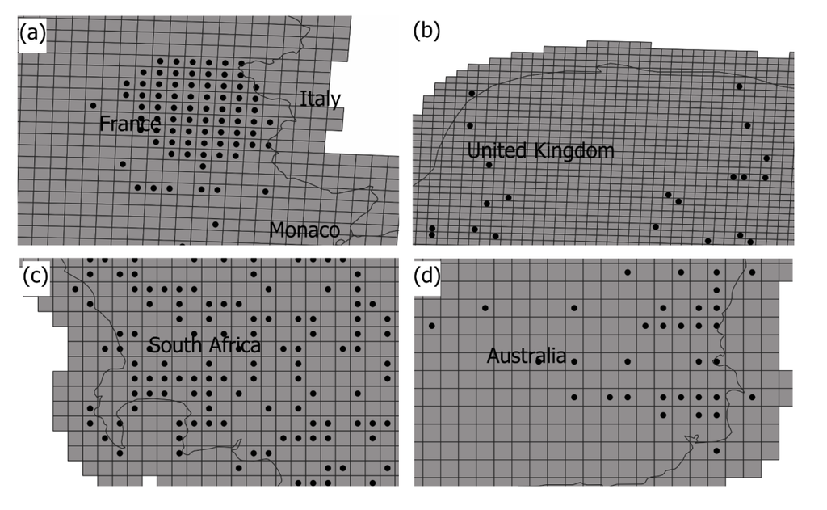

# 6 Major use cases

## 6.1 Infer CRS (coordinate reference system)

First load the demo occurrence data. This dataset includes a group of gridded coordinates. It was originally downloaded from GBIF [https://doi.org/10.15468/dl.fp5795; accessed on 29 November 2021], but has been simplified to be spatially unique points for easier demonstration.

```r
data("occs_unique") # dataframe of occurrences
print(nrow(occs_unique))
```

```
## [1] 1211
```

```r
print(head(occs_unique))
```

```
## # A tibble: 6 × 3
##    ...1 decimalLatitude decimalLongitude
##   <dbl>           <dbl>            <dbl>
## 1     1            48.3            2.93
## 2     2            48.8            2.12
## 3     3            46.8            0.968
## 4     4            48.4            2.26
## 5     5            48.8            2.52
## 6     6            47.0            0.829
```

Look at the coordinates on a map

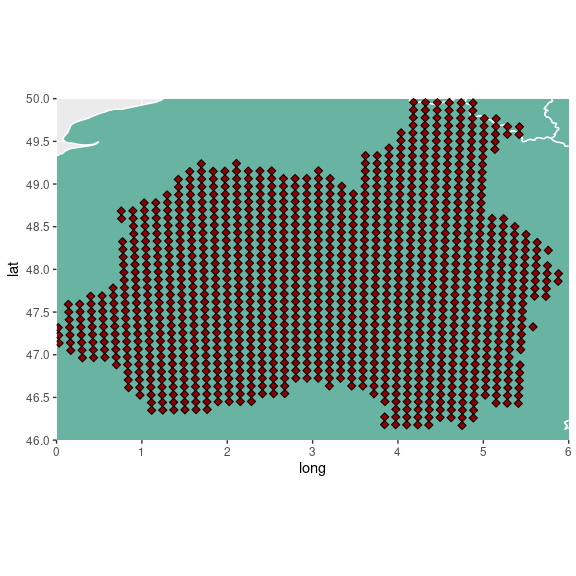

```r
library(ggplot2)
library(broom)

data("ne_10m_admin_0_countries") # load NaturalEarth world map

spdf_fortified = broom::tidy(ne_10m_admin_0_countries, region = "ADMIN")

ggplot2::ggplot() +
  geom_polygon(data = spdf_fortified,
               aes( x = long, y = lat, group = group),
               fill="#69b3a2", color="white") +
  geom_point(data = occs_unique,
             aes(x = decimalLongitude, y = decimalLatitude),
             size = 2,
        shape = 23, fill = "darkred") +
    coord_sf(xlim = c(0, 6), ylim = c(46, 50), expand = FALSE)
```

The coordinates have been projected to WGS84 (which is the same for occurrences from GBIF), which could be different from the CRS where the grid system was defined. So here we use infer_crs() to infer the correct CRS.

```r
results_crs = GridDER::infer_crs(occ_path = occs_unique, # input of coordinates
                                 truth_crs_num = "2154", # (optional) here we know the true CRS, just add it here for a comparison with the inferred CRS ,
                                 #flag_debug = c(4363,5451,5981,5982,5991,5992,5425,5424,5422,3901), # (optional) only evaluate a few CRS
                                 cup_num = 4) # the function will loop through many CRS, so using multiple cores can speed up the process. The default uses 2 cores, but you can adjust it to your preferred number.
```

It may take minutes - hours to complete the inference. If you want to quickly look at the output, you can load the results we calculated earlier.

```r
results_crs = system.file("extdata", "results_crs.rds", package = "GridDER")
results_crs = readRDS(results_crs)
# Now, let's take a look at the output. The CRS code "2154" is ranked the first.
print(results_crs$selected[1:10, c("code", "note")])
```

```
##       code                                  note
## 1     2154                                 truth
## 1336  2154                    RGF93 / Lambert-93
## 6350  5698 RGF93 / Lambert-93 + NGF-IGN69 height
## 6351  5699 RGF93 / Lambert-93 + NGF-IGN78 height
## 4355  3947                          RGF93 / CC47
## 4354  3946                          RGF93 / CC46
## 2944 30731       Nord Sahara 1959 / UTM zone 31N
## 3515 32431               WGS 72BE / UTM zone 31N
## 4353  3945                          RGF93 / CC45
## 4352  3944                          RGF93 / CC44
```

## 6.2 Infer the spatial resolution

```r
data("occs_unique") # Dataframe of occurrences

# Transform the coordinates to be spatial objects
input_occ = GridDER::load_occ(occs_unique)
```

```r
input_occ_prj = sp::spTransform(input_occ,crs(paste0("+init=epsg:","2154")))
result_res = GridDER::infer_resolution(input_coord=input_occ_prj@coords)
print(result_res$res_x)
```

```
## [1] 10000
```

```r
print(result_res$res_y)
```

```
## [1] 10000
```

The inferred resolution is 10km on x & y axes

## 6.3 Infer the spatial extent

```r
result_ext = GridDER::infer_extent(method="crs_extent",
                          crs_grid=results_crs$selected$code[1],
                          flag_adjust_by_res=TRUE,
                          res_x=result_res$res_x,
                          res_y=result_res$res_y)

print(result_ext)
```

```
## [1] -380000 6000000 1320000 7230000
```

## 6.4 Generation of a grid system based on its spatial attributes

```r
simulated_grid = GridDER::grid_generation(res_x=result_res$res_x, # resolution along x-axis
                                          res_y=result_res$res_y, # resolution along y-axis
                                          crs_num=results_crs$selected$code[1], # use the inferred CRS
                                          country="France",       # the spatial file will be masked by country
                      flag_maskByCountry=TRUE,
                                          extent_unit="empirical_occ_extent",
                                          input_extent=result_ext,# use the inferred spatial extent
                                          flag_offset=c(0,-result_res$res_y*10,
                                                        result_res$res_x*10,0) # adjustment of the spatial extent
                                          )
```

```
## [1] "load CountryPolygon"
```

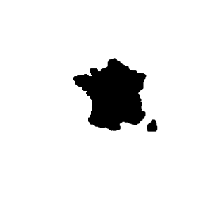

```r
plot(simulated_grid)
```

Check the simulated grid

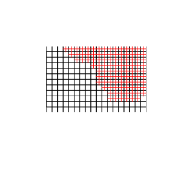

```r
plot(simulated_grid,
     #ext=extent(c(extent(input_occ_prj)[1],extent(input_occ_prj)[1]+100000,
     #           extent(input_occ_prj)[3],extent(input_occ_prj)[3]+100000)))
      xlim=c(extent(input_occ_prj)[1],extent(input_occ_prj)[1]+110000),
      ylim=c(extent(input_occ_prj)[3],extent(input_occ_prj)[3]+110000))
plot(input_occ_prj,add=T,col="red")
```

## 6.5 Match occ data set against known grid systems

[figure not shown]

```r
# take 100 gridded points, and generate 100 random points
point_grid = input_occ[sample(1:length(input_occ),100),]
point_nongrid = point_grid
point_nongrid@coords=point_nongrid@coords+runif(100)
point_all=rbind(point_grid,point_nongrid)

plot(input_occ)
plot(point_grid,add=T, col="red")      # red is gridded coordinate
plot(point_nongrid,add=T,col="orange") # orange is random (nongridded) coordinate
```

### 6.5.1 Grid metadata

We have compiled metadata for 34 grid systems, you could take a look at the table below.

```r
meta_data <- gsheet::gsheet2tbl("https://docs.google.com/spreadsheets/d/1Qp5KOpLSVnF2t16uIbNwKwK5ZBXt4k5unONp7eopPzI/edit#gid=166945453")

meta_data
```

```
## # A tibble: 34 × 14
##    grid_ID \nISO-3166\…¹ count…² crs_t…³ crs_c…⁴ grid_…⁵ resol…⁶ resol…⁷ resol…⁸
##      <dbl> <chr>         <chr>   <chr>   <chr>   <chr>     <dbl>   <dbl> <chr>
##  1       2 FR            France  EPSG    2154    Grille…      10      10 km
##  2       3 FR            France  EPSG    2975    Grille…      10      10 km
##  3       5 NL            Nether… EPSG    28992   Amersf…       1       1 km
##  4       6 BE            Belgium from_s… n/a     <NA>          4       4 km
##  5       7 BE            Belgium from_s… n/a     <NA>          1       1 km
##  6       8 CH            Switze… EPSG    2056    <NA>          5       5 km
##  7       9 RU            Russia  EPSG    4326    <NA>         10       5 minute
##  8      10 RU            Russia  EPSG    4326    <NA>         30      30 minute
##  9      11 BG,GR,RO,RS,… Bulgar… EPSG    4326    eoagri…      30      30 minute
## 10      12 SE            Sweden  EPSG    3021    The Sw…      25      25 km
## # … with 24 more rows, 5 more variables: extent <chr>, extent_unit <chr>,
## #   path_demo_occ <chr>, spatial_uncertainty_mean_grid <dbl>,
## #   spatial_uncertainty_mean_nongrid <dbl>, and abbreviated variable names
## #   ¹`\nISO-3166\nalpha2_https://www.geonames.org/countries/`, ²country_name,
## #   ³crs_type, ⁴crs_code, ⁵grid_name, ⁶resolution_x, ⁷resolution_y,
## #   ⁸resolution_unit
```

Here, we simulated a grid based on the spatial attributes we just inferred.

```r
grid_metadata = data.frame(grid_ID=c("88"),
                           resolution_x=c(10000),
                           resolution_y=c(10000)  )

temp_result = GridDER::grid_matching(input_occ=point_all,
                                     input_grid=simulated_grid,
                                     grid_metadata=grid_metadata,
                                     flag_relativeTHD=0.1,
                                     flag_absoluteTHD=10)
```

```
## input 200 occ
## checking 1 grid out of 1[1] 1
```

```r
# 100 points were recognized to be gridded coordinates
print( table(temp_result@data$grid_closest_both))
```

```
##
## grid_ID_88   notFound
##        100        100
```

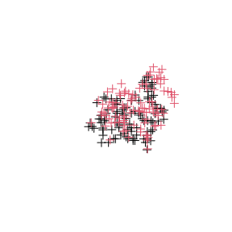

```r
plot(temp_result,col=as.factor(temp_result@data$grid_closest_both))
```

## 6.6 Compute variation of environmental conditions

```r
rgee::ee_Initialize() # The follow command authorizes rgee to manage Earth Engine resources
```

```r
# Load ImageCollection of interest (environmental layer)

nasadem = rgee::ee$Image('NASA/NASADEM_HGT/001')$select('elevation') # Global elevation data in 30 meters. We do not plot due to extension and resolution

# Grid Id 9
data("grid_ID_9") # Grid system example available in the package

grid = grid_ID_9 |>
  rgee::sf_as_ee()
# Compute standard deviation

std_dev <- GridDER::assess_env_uncertainty(x= nasadem, y= grid)
```

```
## [1] "Extracting information [0/336]..."
## Number of features: Calculating ...
Number of features: 336
```

```r
print(std_dev, n=5)
```

```
## Simple feature collection with 336 features and 12 fields
## Geometry type: POLYGON
## Dimension:     XY
## Bounding box:  xmin: 38.1667 ymin: 55.0833 xmax: 43 ymax: 56.8333
## Geodetic CRS:  WGS 84
## First 5 features:
##   Name alttdMd begin drwOrdr    dscrptn end extrude icon tessllt timstmp
## 1   ?1      NA    NA      NA ??????? ?1  NA       0   NA      -1      NA
## 2   ?2      NA    NA      NA ??????? ?2  NA       0   NA      -1      NA
## 3   ?3      NA    NA      NA ??????? ?3  NA       0   NA      -1      NA
## 4   ?1      NA    NA      NA ??????? ?1  NA       0   NA      -1      NA
## 5   ?2      NA    NA      NA ??????? ?2  NA       0   NA      -1      NA
##   visblty elevation                       geometry
## 1      -1 12.579737 POLYGON ((39.5 56.75, 39.66...
## 2      -1  6.765410 POLYGON ((39.6667 56.75, 39...
## 3      -1  6.164659 POLYGON ((39.8333 56.7083, ...
## 4      -1 13.234414 POLYGON ((39.3333 56.6667, ...
## 5      -1  7.550874 POLYGON ((39.5 56.6667, 39....
```

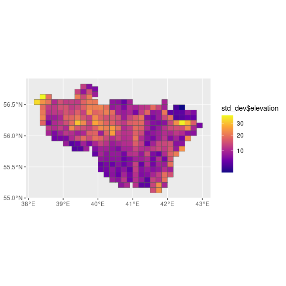

```r
# Plot
library(ggplot2)
ggplot(data = grid_ID_9) +
  geom_sf(aes(fill = std_dev$elevation))+
  scale_fill_viridis_c(option = "plasma", trans = "sqrt")
```

Note the you need to setup rgee package (R package to acessess Google Earth Engine API) before using assessing the environmental variation (assess_env_uncertainty). You may need to use the following code to do so.

```r
rgee::ee_install() # Creating virtual environmental to install the necessary dependencies

# If the following message happen : `An error occur when ee_install was creating the Python Environment. Run ee_clean_pyenv() and restart the R session, before trying again`

# Then execute the bellow command and restart R session:

rgee::ee_clean_pyenv()

# After that you must run `rgee::ee_install()`. You will request to continues and Rstart R seccion choose Yes in all options.

rgee::ee_Initialize() # The follow command authorizes rgee to manage Earth Engine resources

rgee::ee_check() # Checks if everything is OK. Optinal command .
```

## 6.7 A simplified workflow for grid inference and matching

```r
library(GridDER)

#1. (mandatory) specify input coordinates (dataframe, tibble, or the path of a csv) with columns "decimalLatitude" "decimalLongitude"
input_occ = occs_unique # a demo dataset is used here

#2. (optional) specify the crs. flag_crs=NULL will activate the crs inferring process, specifying a EPSG code of a crs will skip the crs inferring process
flag_crs = NULL
possible_true_crs = "2154" #a crs code that will be used as a reference, to be compared with many other crs codes; 2154 is the original crs for the demo dataset.
cup_num = 15 # number of cpus to be used in the inferring process

#3. (optional) specify the resolution of the grid along x and y, e.g. flag_res= c(1000,1000). NULL will activate the resolution inferring process
flag_res = NULL

#4. (optional) specify the spatial extent of the grid, e.g. flag_extent= c(xmin, ymin, xmax, ymax). NULL will activate the extent inferring process
flag_extent = NULL

#5. (optional) generate a grid based on crs, resolution, extent.
flag_generateGrid = TRUE

#6. (optional) match input coordinates to the simulated grid
flag_matchOccToGrid = TRUE

#7. (optional) plot input coordinates and grid
flag_plot = TRUE

#######################
if(is.null(flag_crs)) {
#1.1 Infer coordinate reference system
result_crs = infer_crs(occ_path=input_occ,
                       truth_crs_num = possible_true_crs,
                       cup_num =cup_num)
#results_crs = readRDS(system.file("extdata", "results_crs.rds", package = "GridDER"))
flag_crs =  results_crs$selected$code[1]
}
print(flag_crs)

if( is.null(flag_res) ){
 temp_occ = load_occ(input_occ)
 input_occ_prj = sp::spTransform(temp_occ,crs(paste0("+init=epsg:",flag_crs)))
 result_res = infer_resolution(input_coord=input_occ_prj@coords)
 flag_res = c(result_res$res_x,result_res$res_y)
}
print(flag_res)


if( is.null(flag_extent) ){
result_ext = infer_extent(method = "crs_extent",
                          crs_grid = flag_crs,
                          flag_adjust_by_res = TRUE,
                          res_x = flag_res[1],
                          res_y = flag_res[1])
flag_extent = result_ext
}
print(flag_extent)

if(flag_generateGrid  ){
simulated_grid = grid_generation(res_x = flag_res[1],
                                 res_y = flag_res[2],
                                 extent_unit="empirical_occ_extent",
                                 input_extent=result_ext,
                                 flag_offset=c(0,-flag_res[2]*10,
                                               flag_res[1]*10,0),
                                                 crs_num = flag_crs,
                                                 flag_maskByCountry = FALSE)
}



if(flag_matchOccToGrid){
  point_grid = load_occ(input_occ)

  grid_metadata = data.frame(grid_ID= c("simulatedGrid"),
                            resolution_x=flag_res[1],
                            resolution_y=flag_res[2] )

  temp_result = grid_matching(input_occ = point_grid,
                                input_grid = simulated_grid,
                                grid_metadata=grid_metadata,
                                flag_relativeTHD = 0.1,
                                flag_absoluteTHD = 100)
  table(temp_result@data$grid_closest_both)
}

if(flag_plot){
  temp_result_prj = sp::spTransform(temp_result,crs(paste0("+init=epsg:",flag_crs)))
  simulated_grid_crop = crop(simulated_grid,extent(temp_result_prj))
  plot(simulated_grid_crop )
  plot(temp_result_prj,add=T,col="blue")
}
```